# Week 3 Case Study: RNN & LSTM for Sequence Modeling

**Student Name:** Siddhartha Mukherjee

**Course:** Applied Research Topics in Deep Learning

**Date:** 2026-04-26

### Install required libraries

```python
!pip install tensorflow tensorflow-datasets nltk matplotlib seaborn scikit-learn -q
```

### Import all libraries and set random seeds

```python
import numpy as np
import pandas as pd
import matplotlib.pyplot as plt
import seaborn as sns
import tensorflow as tf
from tensorflow import keras
from tensorflow.keras import layers, models, optimizers, callbacks
from tensorflow.keras.preprocessing.text import Tokenizer
from tensorflow.keras.preprocessing.sequence import pad_sequences
import tensorflow_datasets as tfds
import nltk
import re
import time
from collections import Counter
from sklearn.metrics import classification_report, confusion_matrix

nltk.download('punkt', quiet=True)
nltk.download('stopwords', quiet=True)
nltk.download('punkt_tab', quiet=True)

np.random.seed(42)
tf.random.set_seed(42)

print("TensorFlow version:", tf.__version__)
print("GPU available:", tf.config.list_physical_devices('GPU'))
```

```
TensorFlow version: 2.19.0
GPU available: [PhysicalDevice(name='/physical_device:GPU:0', device_type='GPU')]
```

### Load IMDB dataset and show sample reviews

```python
# Load IMDB dataset (positive or negative reviews)
(ds_train, ds_test), ds_info = tfds.load(
    "imdb_reviews",
    split=["train", "test"],
    with_info=True,
    as_supervised=True
)

print(ds_info)
print("\n--- Sample Reviews ---")
for example, label in ds_train.take(3):
    print("Review:", example.numpy().decode('utf-8')[:200], "...")
    print("Label:", "Positive" if label.numpy() == 1 else "Negative")
    print()
```

```
WARNING:absl:Variant folder /root/tensorflow_datasets/imdb_reviews/plain_text/1.0.0 has no dataset_info.json
```

```
Downloading and preparing dataset Unknown size (download: Unknown size, generated: Unknown size, total: Unknown size) to /root/tensorflow_datasets/imdb_reviews/plain_text/1.0.0...
```

```
Dl Completed...: 0 url [00:00, ? url/s]
```

```
Dl Size...: 0 MiB [00:00, ? MiB/s]
```

```
Generating train examples...: 0 examples [00:00, ? examples/s]
```

```
Shuffling /root/tensorflow_datasets/imdb_reviews/plain_text/incomplete.MAKSOT_1.0.0/imdb_reviews-train.tfrecor…
```

```
Generating test examples...: 0 examples [00:00, ? examples/s]
```

```
Shuffling /root/tensorflow_datasets/imdb_reviews/plain_text/incomplete.MAKSOT_1.0.0/imdb_reviews-test.tfrecord…
```

```
Generating unsupervised examples...: 0 examples [00:00, ? examples/s]
```

```
Shuffling /root/tensorflow_datasets/imdb_reviews/plain_text/incomplete.MAKSOT_1.0.0/imdb_reviews-unsupervised.…
```

```
Dataset imdb_reviews downloaded and prepared to /root/tensorflow_datasets/imdb_reviews/plain_text/1.0.0. Subsequent calls will reuse this data.
tfds.core.DatasetInfo(
    name='imdb_reviews',
    full_name='imdb_reviews/plain_text/1.0.0',
    description="""
    Large Movie Review Dataset. This is a dataset for binary sentiment
    classification containing substantially more data than previous benchmark
    datasets. We provide a set of 25,000 highly polar movie reviews for training,
    and 25,000 for testing. There is additional unlabeled data for use as well.
    """,
    config_description="""
    Plain text
    """,
    homepage='http://ai.stanford.edu/~amaas/data/sentiment/',
    data_dir='/root/tensorflow_datasets/imdb_reviews/plain_text/1.0.0',
    file_format=tfrecord,
    download_size=80.23 MiB,
    dataset_size=129.83 MiB,
    features=FeaturesDict({
        'label': ClassLabel(shape=(), dtype=int64, num_classes=2),
        'text': Text(shape=(), dtype=string),
    }),
    supervised_keys=('text', 'label'),
    disable_shuffling=False,
    nondeterministic_order=False,
    splits={
        'test': <SplitInfo num_examples=25000, num_shards=1>,
        'train': <SplitInfo num_examples=25000, num_shards=1>,
        'unsupervised': <SplitInfo num_examples=50000, num_shards=1>,
    },
    citation="""@InProceedings{maas-EtAl:2011:ACL-HLT2011,
      author    = {Maas, Andrew L.  and  Daly, Raymond E.  and  Pham, Peter T.  and  Huang, Dan  and  Ng, Andrew Y.  and  Potts, Christopher},
      title     = {Learning Word Vectors for Sentiment Analysis},
      booktitle = {Proceedings of the 49th Annual Meeting of the Association for Computational Linguistics: Human Language Technologies},
      month     = {June},
      year      = {2011},
      address   = {Portland, Oregon, USA},
      publisher = {Association for Computational Linguistics},
      pages     = {142--150},
      url       = {http://www.aclweb.org/anthology/P11-1015}
    }""",
)

--- Sample Reviews ---
Review: This was an absolutely terrible movie. Don't be lured in by Christopher Walken or Michael Ironside. Both are great actors, but this must simply be their worst role in history. Even their great acting  ...
Label: Negative

Review: I have been known to fall asleep during films, but this is usually due to a combination of things including, really tired, being warm and comfortable on the sette and having just eaten a lot. However  ...
Label: Negative

Review: Mann photographs the Alberta Rocky Mountains in a superb fashion, and Jimmy Stewart and Walter Brennan give enjoyable performances as they always seem to do. <br /><br />But come on Hollywood - a Moun ...
Label: Negative
```

### Extract all reviews and labels into Python lists

```python
# Pull all reviews and labels into Python lists
train_texts = []
train_labels = []
for text, label in ds_train:
    train_texts.append(text.numpy().decode('utf-8'))
    train_labels.append(label.numpy())

test_texts = []
test_labels = []
for text, label in ds_test:
    test_texts.append(text.numpy().decode('utf-8'))
    test_labels.append(label.numpy())

train_labels = np.array(train_labels)
test_labels = np.array(test_labels)

print(f"Training samples: {len(train_texts)}")
print(f"Test samples: {len(test_texts)}")
print(f"Label distribution (train): Pos={sum(train_labels)}, Neg={len(train_labels)-sum(train_labels)}")
```

```
Training samples: 25000
Test samples: 25000
Label distribution (train): Pos=12500, Neg=12500
```

## Part 1 — Text Preprocessing & Sequence Preparation

### Clean text by removing HTML tags, special characters, and converting to lowercase

```python
# Clean text: remove HTML, special characters, make lowercase
def clean_text(text):
    text = re.sub(r'<[^>]+>', '', text)        # remove HTML tags like <br>
    text = re.sub(r'[^a-zA-Z\s]', '', text)    # keep only letters and spaces
    text = text.lower().strip()
    return text

train_texts_clean = [clean_text(t) for t in train_texts]
test_texts_clean = [clean_text(t) for t in test_texts]

print("Before cleaning:", train_texts[0][:150])
print("\nAfter cleaning:", train_texts_clean[0][:150])
```

```
Before cleaning: This was an absolutely terrible movie. Don't be lured in by Christopher Walken or Michael Ironside. Both are great actors, but this must simply be the

After cleaning: this was an absolutely terrible movie dont be lured in by christopher walken or michael ironside both are great actors but this must simply be their w
```

### Analyze review lengths — mean, median, percentiles

```python
# Check how long the reviews are (in words)
train_word_counts = [len(t.split()) for t in train_texts_clean]

print("Review Length Stats (words):")
print(f"  Mean:   {np.mean(train_word_counts):.0f}")
print(f"  Median: {np.median(train_word_counts):.0f}")
print(f"  Min:    {np.min(train_word_counts)}")
print(f"  Max:    {np.max(train_word_counts)}")
print(f"  Std:    {np.std(train_word_counts):.0f}")
print(f"  90th percentile: {np.percentile(train_word_counts, 90):.0f}")
print(f"  95th percentile: {np.percentile(train_word_counts, 95):.0f}")
```

```
Review Length Stats (words):
  Mean:   228
  Median: 170
  Min:    10
  Max:    2441
  Std:    169
  90th percentile: 446
  95th percentile: 583
```

### Plot 1: Review length distribution (histogram and box plot)

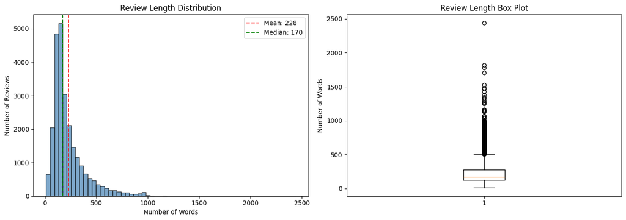

```python
fig, axes = plt.subplots(1, 2, figsize=(14, 5))

axes[0].hist(train_word_counts, bins=60, color='steelblue', edgecolor='black', alpha=0.7)
axes[0].axvline(np.mean(train_word_counts), color='red', linestyle='--', label=f'Mean: {np.mean(train_word_counts):.0f}')
axes[0].axvline(np.median(train_word_counts), color='green', linestyle='--', label=f'Median: {np.median(train_word_counts):.0f}')
axes[0].set_xlabel('Number of Words')
axes[0].set_ylabel('Number of Reviews')
axes[0].set_title('Review Length Distribution')
axes[0].legend()

axes[1].boxplot(train_word_counts, vert=True)
axes[1].set_ylabel('Number of Words')
axes[1].set_title('Review Length Box Plot')

plt.tight_layout()
plt.show()
```

### Tokenize text and build a vocabulary of top 20,000 words

```python
VOCAB_SIZE = 20000    # keep top 20,000 words
MAX_LEN = 250         # max sequence length
EMBEDDING_DIM = 100   # word vector size

# Fit tokenizer on training data only
tokenizer = Tokenizer(num_words=VOCAB_SIZE, oov_token='<OOV>')
tokenizer.fit_on_texts(train_texts_clean)

# Turn words into numbers
train_sequences = tokenizer.texts_to_sequences(train_texts_clean)
test_sequences = tokenizer.texts_to_sequences(test_texts_clean)

word_index = tokenizer.word_index
print(f"Total unique words: {len(word_index)}")
print(f"Vocabulary used: {VOCAB_SIZE}")
print(f"\nSample word-to-number mapping:")
for word, idx in list(word_index.items())[:10]:
    print(f"  '{word}' -> {idx}")
```

```
Total unique words: 138402
Vocabulary used: 20000

Sample word-to-number mapping:
  '<OOV>' -> 1
  'the' -> 2
  'and' -> 3
  'a' -> 4
  'of' -> 5
  'to' -> 6
  'is' -> 7
  'in' -> 8
  'it' -> 9
  'this' -> 10
```

### Plot 2: Word frequency distribution and Zipf's law

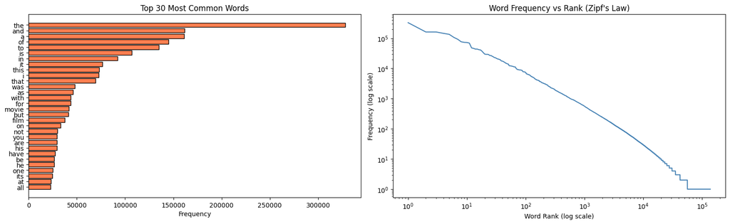

```python
all_words = ' '.join(train_texts_clean).split()
word_freq = Counter(all_words)
top_30 = word_freq.most_common(30)

words = [w[0] for w in top_30]
counts = [w[1] for w in top_30]

fig, axes = plt.subplots(1, 2, figsize=(16, 5))

axes[0].barh(words[::-1], counts[::-1], color='coral', edgecolor='black')
axes[0].set_xlabel('Frequency')
axes[0].set_title('Top 30 Most Common Words')

freq_values = sorted(word_freq.values(), reverse=True)
axes[1].plot(range(1, len(freq_values)+1), freq_values, color='steelblue')
axes[1].set_xscale('log')
axes[1].set_yscale('log')
axes[1].set_xlabel('Word Rank (log scale)')
axes[1].set_ylabel('Frequency (log scale)')
axes[1].set_title("Word Frequency vs Rank (Zipf's Law)")

plt.tight_layout()
plt.show()
```

### Pad and truncate all sequences to fixed length of 250

```python
# Make all sequences the same length (250 words)
X_train = pad_sequences(train_sequences, maxlen=MAX_LEN, padding='post', truncating='post')
X_test = pad_sequences(test_sequences, maxlen=MAX_LEN, padding='post', truncating='post')

print(f"Padded training shape: {X_train.shape}")
print(f"Padded test shape: {X_test.shape}")
print(f"\nFirst 20 tokens of review 1: {X_train[0][:20]}")
print(f"Last 20 tokens of review 1:  {X_train[0][-20:]}")
```

```
Padded training shape: (25000, 250)
Padded test shape: (25000, 250)

First 20 tokens of review 1: [   10    13    33   410   382    17    89    26 10199     8    32  1320
  3452    40   488 11236   193    23    84   149]
Last 20 tokens of review 1:  [0 0 0 0 0 0 0 0 0 0 0 0 0 0 0 0 0 0 0 0]
```

### Plot 3: Padding and truncation effect on review lengths

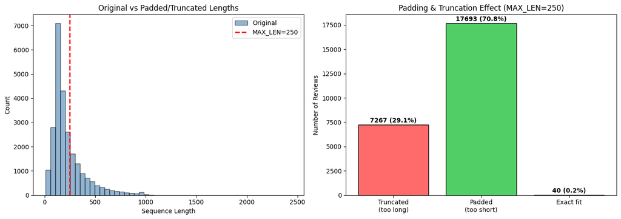

```
Summary: 7267 truncated, 17693 padded, 40 exact fit
```

```python
original_lengths = [len(s) for s in train_sequences]

fig, axes = plt.subplots(1, 2, figsize=(14, 5))

axes[0].hist(original_lengths, bins=50, alpha=0.6, label='Original', color='steelblue', edgecolor='black')
axes[0].axvline(MAX_LEN, color='red', linestyle='--', linewidth=2, label=f'MAX_LEN={MAX_LEN}')
axes[0].set_xlabel('Sequence Length')
axes[0].set_ylabel('Count')
axes[0].set_title('Original vs Padded/Truncated Lengths')
axes[0].legend()

truncated = sum(1 for l in original_lengths if l > MAX_LEN)
padded = sum(1 for l in original_lengths if l < MAX_LEN)
exact = sum(1 for l in original_lengths if l == MAX_LEN)

labels_bar = ['Truncated\n(too long)', 'Padded\n(too short)', 'Exact fit']
sizes = [truncated, padded, exact]
colors_bar = ['#ff6b6b', '#51cf66', '#339af0']
axes[1].bar(labels_bar, sizes, color=colors_bar, edgecolor='black')
axes[1].set_ylabel('Number of Reviews')
axes[1].set_title(f'Padding & Truncation Effect (MAX_LEN={MAX_LEN})')
for i, v in enumerate(sizes):
    axes[1].text(i, v + 200, f'{v} ({v/len(original_lengths)*100:.1f}%)', ha='center', fontweight='bold')

plt.tight_layout()
plt.show()
print(f"\nSummary: {truncated} truncated, {padded} padded, {exact} exact fit")
```

### Download pre-trained GloVe word vectors (100-dimensional)

```python
!wget -q http://nlp.stanford.edu/data/glove.6B.zip
!unzip -q -o glove.6B.zip glove.6B.100d.txt
print("GloVe downloaded!")
```

```
GloVe downloaded!
```

### Build embedding matrix by mapping our vocabulary to GloVe vectors

```python
# Load GloVe vectors into a dictionary
glove_embeddings = {}
with open('glove.6B.100d.txt', 'r', encoding='utf-8') as f:
    for line in f:
        parts = line.split()
        word = parts[0]
        vector = np.array(parts[1:], dtype='float32')
        glove_embeddings[word] = vector

print(f"GloVe vectors loaded: {len(glove_embeddings)} words")

# Make an embedding matrix for our vocabulary
embedding_matrix = np.zeros((VOCAB_SIZE, EMBEDDING_DIM))
found = 0
not_found = 0

for word, idx in word_index.items():
    if idx >= VOCAB_SIZE:
        continue
    vec = glove_embeddings.get(word)
    if vec is not None:
        embedding_matrix[idx] = vec
        found += 1
    else:
        not_found += 1

print(f"Words found in GloVe: {found}")
print(f"Words NOT found: {not_found}")
print(f"Coverage: {found/(found+not_found)*100:.1f}%")
```

```
GloVe vectors loaded: 400000 words
Words found in GloVe: 19179
Words NOT found: 820
Coverage: 95.9%
```

### Split training data into train (80%) and validation (20%) sets

```python
VAL_SPLIT = 0.2
num_val = int(len(X_train) * VAL_SPLIT)

indices = np.random.permutation(len(X_train))
X_train_shuffled = X_train[indices]
y_train_shuffled = train_labels[indices]

X_val = X_train_shuffled[:num_val]
y_val = y_train_shuffled[:num_val]
X_train_final = X_train_shuffled[num_val:]
y_train_final = y_train_shuffled[num_val:]

print(f"Training: {X_train_final.shape[0]} samples")
print(f"Validation: {X_val.shape[0]} samples")
print(f"Test: {X_test.shape[0]} samples")
```

```
Training: 20000 samples
Validation: 5000 samples
Test: 25000 samples
```

## Part 2 — RNN Architecture Comparison

### Define a helper function to build different RNN model types

```python
def build_rnn_model(rnn_type='LSTM', num_layers=1, bidirectional=False,
                    units=64, use_glove=True):
    model = models.Sequential()

    if use_glove:
        model.add(layers.Embedding(VOCAB_SIZE, EMBEDDING_DIM,
                                   weights=[embedding_matrix],
                                   trainable=False))
    else:
        model.add(layers.Embedding(VOCAB_SIZE, EMBEDDING_DIM))

    rnn_map = {
        'SimpleRNN': layers.SimpleRNN,
        'LSTM': layers.LSTM,
        'GRU': layers.GRU
    }
    RNNLayer = rnn_map[rnn_type]

    for i in range(num_layers):
        return_seq = (i < num_layers - 1)
        rnn = RNNLayer(units, return_sequences=return_seq,
                       dropout=0.2, recurrent_dropout=0.2)
        if bidirectional:
            model.add(layers.Bidirectional(rnn))
        else:
            model.add(rnn)

    model.add(layers.Dense(32, activation='relu'))
    model.add(layers.Dropout(0.3))
    model.add(layers.Dense(1, activation='sigmoid'))

    model.compile(optimizer='adam', loss='binary_crossentropy', metrics=['accuracy'])
    return model

print("Model builder ready!")
```

```
Model builder ready!
```

### Train 7 RNN models: SimpleRNN, LSTM, GRU (single/multi-layer, uni/bidirectional)

```python
EPOCHS = 5
BATCH_SIZE = 64

model_configs = [
    {'name': 'SimpleRNN (1-layer)',  'rnn_type': 'SimpleRNN', 'num_layers': 1, 'bidirectional': False},
    {'name': 'LSTM (1-layer)',       'rnn_type': 'LSTM',      'num_layers': 1, 'bidirectional': False},
    {'name': 'GRU (1-layer)',        'rnn_type': 'GRU',       'num_layers': 1, 'bidirectional': False},
    {'name': 'LSTM (2-layer)',       'rnn_type': 'LSTM',      'num_layers': 2, 'bidirectional': False},
    {'name': 'GRU (2-layer)',        'rnn_type': 'GRU',       'num_layers': 2, 'bidirectional': False},
    {'name': 'Bi-LSTM (1-layer)',    'rnn_type': 'LSTM',      'num_layers': 1, 'bidirectional': True},
    {'name': 'Bi-GRU (1-layer)',     'rnn_type': 'GRU',       'num_layers': 1, 'bidirectional': True},
]

all_histories = {}
all_results = []

for config in model_configs:
    print(f"\n{'='*60}")
    print(f"Training: {config['name']}")
    print(f"{'='*60}")

    model = build_rnn_model(
        rnn_type=config['rnn_type'],
        num_layers=config['num_layers'],
        bidirectional=config['bidirectional']
    )

    # Build the model so it knows the input shape
    model.build(input_shape=(None, MAX_LEN))
    total_params = model.count_params()
    print(f"Total parameters: {total_params:,}")

    start_time = time.time()
    history = model.fit(
        X_train_final, y_train_final,
        epochs=EPOCHS, batch_size=BATCH_SIZE,
        validation_data=(X_val, y_val), verbose=1
    )
    train_time = time.time() - start_time

    test_loss, test_acc = model.evaluate(X_test, test_labels, verbose=0)

    all_histories[config['name']] = history.history
    all_results.append({
        'Model': config['name'],
        'Train Acc': f"{history.history['accuracy'][-1]:.4f}",
        'Val Acc': f"{history.history['val_accuracy'][-1]:.4f}",
        'Test Acc': f"{test_acc:.4f}",
        'Test Loss': f"{test_loss:.4f}",
        'Params': f"{total_params:,}",
        'Time (s)': f"{train_time:.1f}"
    })
    print(f"Test Accuracy: {test_acc:.4f} | Time: {train_time:.1f}s")
```

```
============================================================
Training: SimpleRNN (1-layer)
============================================================
Total parameters: 2,012,673
313/313 ━━━━━━━━━━━━━━━━━━━━ 13s 29ms/step - accuracy: 0.5026 - loss: 0.7061 - val_accuracy: 0.5146 - val_loss: 0.6922
313/313 ━━━━━━━━━━━━━━━━━━━━ 6s 20ms/step - accuracy: 0.5072 - loss: 0.6968 - val_accuracy: 0.5050 - val_loss: 0.6929
313/313 ━━━━━━━━━━━━━━━━━━━━ 6s 20ms/step - accuracy: 0.5031 - loss: 0.6956 - val_accuracy: 0.4960 - val_loss: 0.6945
313/313 ━━━━━━━━━━━━━━━━━━━━ 6s 20ms/step - accuracy: 0.4981 - loss: 0.6956 - val_accuracy: 0.5076 - val_loss: 0.6931
313/313 ━━━━━━━━━━━━━━━━━━━━ 6s 20ms/step - accuracy: 0.5069 - loss: 0.6937 - val_accuracy: 0.5198 - val_loss: 0.6928
Test Accuracy: 0.5075 | Time: 38.7s

============================================================
Training: LSTM (1-layer)
============================================================
Total parameters: 2,044,353
313/313 ━━━━━━━━━━━━━━━━━━━━ 172s 531ms/step - accuracy: 0.5120 - loss: 0.6926 - val_accuracy: 0.5446 - val_loss: 0.6820
313/313 ━━━━━━━━━━━━━━━━━━━━ 165s 528ms/step - accuracy: 0.5314 - loss: 0.6859 - val_accuracy: 0.5474 - val_loss: 0.6691
313/313 ━━━━━━━━━━━━━━━━━━━━ 167s 533ms/step - accuracy: 0.5793 - loss: 0.6715 - val_accuracy: 0.5370 - val_loss: 0.6758
313/313 ━━━━━━━━━━━━━━━━━━━━ 165s 526ms/step - accuracy: 0.5577 - loss: 0.6718 - val_accuracy: 0.5726 - val_loss: 0.6511
313/313 ━━━━━━━━━━━━━━━━━━━━ 166s 529ms/step - accuracy: 0.6525 - loss: 0.6345 - val_accuracy: 0.7302 - val_loss: 0.5764
Test Accuracy: 0.7198 | Time: 834.6s

============================================================
Training: GRU (1-layer)
============================================================
Total parameters: 2,033,985
313/313 ━━━━━━━━━━━━━━━━━━━━ 159s 499ms/step - accuracy: 0.5078 - loss: 0.6932 - val_accuracy: 0.5118 - val_loss: 0.6892
313/313 ━━━━━━━━━━━━━━━━━━━━ 156s 498ms/step - accuracy: 0.5314 - loss: 0.6861 - val_accuracy: 0.5458 - val_loss: 0.6675
313/313 ━━━━━━━━━━━━━━━━━━━━ 156s 499ms/step - accuracy: 0.6159 - loss: 0.6552 - val_accuracy: 0.7312 - val_loss: 0.5984
313/313 ━━━━━━━━━━━━━━━━━━━━ 156s 500ms/step - accuracy: 0.6381 - loss: 0.6359 - val_accuracy: 0.7278 - val_loss: 0.5788
313/313 ━━━━━━━━━━━━━━━━━━━━ 158s 505ms/step - accuracy: 0.6184 - loss: 0.6400 - val_accuracy: 0.5656 - val_loss: 0.6524
Test Accuracy: 0.5729 | Time: 785.9s

============================================================
Training: LSTM (2-layer)
============================================================
Total parameters: 2,077,377
313/313 ━━━━━━━━━━━━━━━━━━━━ 381s 1s/step - accuracy: 0.5138 - loss: 0.6909 - val_accuracy: 0.5430 - val_loss: 0.6769
313/313 ━━━━━━━━━━━━━━━━━━━━ 369s 1s/step - accuracy: 0.5289 - loss: 0.6869 - val_accuracy: 0.5420 - val_loss: 0.6738
313/313 ━━━━━━━━━━━━━━━━━━━━ 369s 1s/step - accuracy: 0.5400 - loss: 0.6821 - val_accuracy: 0.5650 - val_loss: 0.6583
```

[output cut: 21 more lines]

```
313/313 ━━━━━━━━━━━━━━━━━━━━ 279s 893ms/step - accuracy: 0.7674 - loss: 0.5010 - val_accuracy: 0.8128 - val_loss: 0.4242
313/313 ━━━━━━━━━━━━━━━━━━━━ 278s 889ms/step - accuracy: 0.7992 - loss: 0.4460 - val_accuracy: 0.8288 - val_loss: 0.3898
313/313 ━━━━━━━━━━━━━━━━━━━━ 279s 891ms/step - accuracy: 0.8147 - loss: 0.4196 - val_accuracy: 0.8420 - val_loss: 0.3660
Test Accuracy: 0.8328 | Time: 1399.6s

============================================================
Training: Bi-GRU (1-layer)
============================================================
Total parameters: 2,067,905
313/313 ━━━━━━━━━━━━━━━━━━━━ 268s 840ms/step - accuracy: 0.6043 - loss: 0.6545 - val_accuracy: 0.7396 - val_loss: 0.5269
313/313 ━━━━━━━━━━━━━━━━━━━━ 265s 846ms/step - accuracy: 0.7628 - loss: 0.4990 - val_accuracy: 0.8020 - val_loss: 0.4295
313/313 ━━━━━━━━━━━━━━━━━━━━ 263s 840ms/step - accuracy: 0.8076 - loss: 0.4348 - val_accuracy: 0.8370 - val_loss: 0.3736
313/313 ━━━━━━━━━━━━━━━━━━━━ 260s 832ms/step - accuracy: 0.8176 - loss: 0.4088 - val_accuracy: 0.8350 - val_loss: 0.3709
313/313 ━━━━━━━━━━━━━━━━━━━━ 260s 832ms/step - accuracy: 0.8318 - loss: 0.3859 - val_accuracy: 0.8558 - val_loss: 0.3400
Test Accuracy: 0.8457 | Time: 1317.0s
```

### Display results table comparing all 7 models

```python
results_df = pd.DataFrame(all_results)
print("\n" + "="*80)
print("MODEL COMPARISON RESULTS")
print("="*80)
print(results_df.to_string(index=False))
```

```
================================================================================
MODEL COMPARISON RESULTS
================================================================================
              Model Train Acc Val Acc Test Acc Test Loss    Params Time (s)
SimpleRNN (1-layer)    0.5069  0.5198   0.5075    0.6933 2,012,673     38.7
     LSTM (1-layer)    0.6525  0.7302   0.7198    0.5826 2,044,353    834.6
      GRU (1-layer)    0.6184  0.5656   0.5729    0.6585 2,033,985    785.9
     LSTM (2-layer)    0.6781  0.7286   0.7193    0.5859 2,077,377   1860.8
      GRU (2-layer)    0.7934  0.8308   0.8219    0.3909 2,058,945   1630.9
  Bi-LSTM (1-layer)    0.8147  0.8420   0.8328    0.3771 2,088,641   1399.6
   Bi-GRU (1-layer)    0.8318  0.8558   0.8457    0.3481 2,067,905   1317.0
```

### Plot training and validation curves (accuracy and loss) for all models

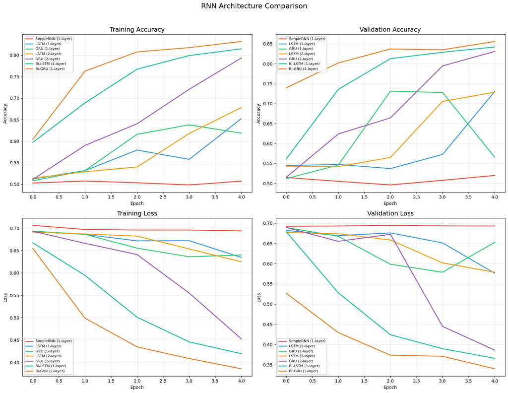

```python
fig, axes = plt.subplots(2, 2, figsize=(16, 12))
colors = ['#e74c3c', '#3498db', '#2ecc71', '#f39c12', '#9b59b6', '#1abc9c', '#e67e22']

for i, (name, hist) in enumerate(all_histories.items()):
    axes[0, 0].plot(hist['accuracy'], label=name, color=colors[i % len(colors)], linewidth=2)
axes[0, 0].set_title('Training Accuracy', fontsize=14)
axes[0, 0].set_xlabel('Epoch'); axes[0, 0].set_ylabel('Accuracy')
axes[0, 0].legend(fontsize=8); axes[0, 0].grid(True, alpha=0.3)

for i, (name, hist) in enumerate(all_histories.items()):
    axes[0, 1].plot(hist['val_accuracy'], label=name, color=colors[i % len(colors)], linewidth=2)
axes[0, 1].set_title('Validation Accuracy', fontsize=14)
axes[0, 1].set_xlabel('Epoch'); axes[0, 1].set_ylabel('Accuracy')
axes[0, 1].legend(fontsize=8); axes[0, 1].grid(True, alpha=0.3)

for i, (name, hist) in enumerate(all_histories.items()):
    axes[1, 0].plot(hist['loss'], label=name, color=colors[i % len(colors)], linewidth=2)
axes[1, 0].set_title('Training Loss', fontsize=14)
axes[1, 0].set_xlabel('Epoch'); axes[1, 0].set_ylabel('Loss')
axes[1, 0].legend(fontsize=8); axes[1, 0].grid(True, alpha=0.3)

for i, (name, hist) in enumerate(all_histories.items()):
    axes[1, 1].plot(hist['val_loss'], label=name, color=colors[i % len(colors)], linewidth=2)
axes[1, 1].set_title('Validation Loss', fontsize=14)
axes[1, 1].set_xlabel('Epoch'); axes[1, 1].set_ylabel('Loss')
axes[1, 1].legend(fontsize=8); axes[1, 1].grid(True, alpha=0.3)

plt.suptitle('RNN Architecture Comparison', fontsize=16, y=1.02)
plt.tight_layout()
plt.show()
```

### Bar chart comparing test accuracy of all RNN models

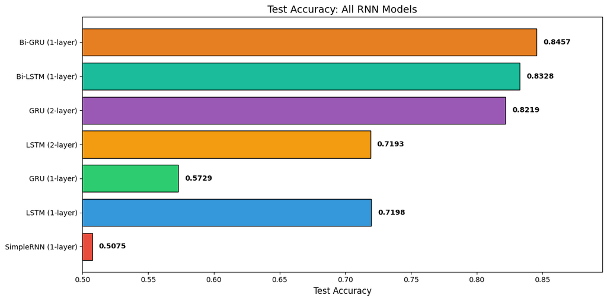

```python
model_names = [r['Model'] for r in all_results]
test_accs = [float(r['Test Acc']) for r in all_results]

plt.figure(figsize=(12, 6))
bars = plt.barh(model_names, test_accs, color=colors[:len(model_names)], edgecolor='black')
plt.xlabel('Test Accuracy', fontsize=12)
plt.title('Test Accuracy: All RNN Models', fontsize=14)
plt.xlim(0.5, max(test_accs) + 0.05)
for bar, acc in zip(bars, test_accs):
    plt.text(acc + 0.005, bar.get_y() + bar.get_height()/2, f'{acc:.4f}', va='center', fontweight='bold')
plt.tight_layout()
plt.show()
```

### Gradient flow study — compare gradient norms across SimpleRNN, LSTM, and GRU

```python
print("Gradient Flow Study: SimpleRNN vs LSTM vs GRU")
print("="*60)

for rnn_type in ['SimpleRNN', 'LSTM', 'GRU']:
    model = build_rnn_model(rnn_type=rnn_type, num_layers=2, units=64)
    sample_x = X_train_final[:32]
    sample_y = y_train_final[:32].reshape(-1, 1).astype('float32')  # reshape to (32, 1)

    with tf.GradientTape() as tape:
        predictions = model(sample_x, training=True)
        loss = tf.keras.losses.binary_crossentropy(sample_y, predictions)

    gradients = tape.gradient(loss, model.trainable_variables)

    print(f"\n{rnn_type} gradient norms:")
    for var, grad in zip(model.trainable_variables, gradients):
        if grad is not None:
            grad_norm = tf.norm(grad).numpy()
            print(f"  {var.name:50s} | norm: {grad_norm:.6f}")

print("\n--- Key Insight ---")
print("SimpleRNN shows very small gradients in early layers (vanishing gradient).")
print("LSTM and GRU keep gradients more stable thanks to their gates.")
```

[output not shown]

## Part 3 — Advanced Sequence Modeling

### Build a custom attention layer and train LSTM with attention

```python
class AttentionLayer(layers.Layer):
    """Learns which time steps matter most."""

    def __init__(self, **kwargs):
        super(AttentionLayer, self).__init__(**kwargs)

    def build(self, input_shape):
        self.W = self.add_weight(name='attention_weight',
                                 shape=(input_shape[-1], 1),
                                 initializer='glorot_uniform', trainable=True)
        self.b = self.add_weight(name='attention_bias',
                                 shape=(input_shape[1], 1),
                                 initializer='zeros', trainable=True)
        super(AttentionLayer, self).build(input_shape)

    def call(self, x):
        score = tf.nn.tanh(tf.matmul(x, self.W) + self.b)
        attention_weights = tf.nn.softmax(score, axis=1)
        context = x * attention_weights
        context = tf.reduce_sum(context, axis=1)
        return context


def build_attention_model(rnn_type='LSTM', use_glove=True):
    inputs = layers.Input(shape=(MAX_LEN,))

    if use_glove:
        x = layers.Embedding(VOCAB_SIZE, EMBEDDING_DIM,
                             weights=[embedding_matrix], trainable=False)(inputs)
    else:
        x = layers.Embedding(VOCAB_SIZE, EMBEDDING_DIM)(inputs)

    rnn_map = {'LSTM': layers.LSTM, 'GRU': layers.GRU}
    x = rnn_map[rnn_type](64, return_sequences=True, dropout=0.2, recurrent_dropout=0.2)(x)
    x = AttentionLayer()(x)
    x = layers.Dense(32, activation='relu')(x)
    x = layers.Dropout(0.3)(x)
    outputs = layers.Dense(1, activation='sigmoid')(x)

    model = models.Model(inputs, outputs)
    model.compile(optimizer='adam', loss='binary_crossentropy', metrics=['accuracy'])
    return model


print("Training LSTM + Attention...")
attn_model = build_attention_model('LSTM', use_glove=True)
attn_model.summary()

attn_history = attn_model.fit(
    X_train_final, y_train_final,
    epochs=EPOCHS, batch_size=BATCH_SIZE,
    validation_data=(X_val, y_val), verbose=1
)

attn_test_loss, attn_test_acc = attn_model.evaluate(X_test, test_labels, verbose=0)
print(f"\nLSTM + Attention Test Accuracy: {attn_test_acc:.4f}")
```

```
Training LSTM + Attention...
```

```
Model: "functional_12"
```

```
┏━━━━━━━━━━━━━━━━━━━━━━━━━━━━━━━━━┳━━━━━━━━━━━━━━━━━━━━━━━━┳━━━━━━━━━━━━━━━┓
┃ Layer (type)                    ┃ Output Shape           ┃       Param # ┃
┡━━━━━━━━━━━━━━━━━━━━━━━━━━━━━━━━━╇━━━━━━━━━━━━━━━━━━━━━━━━╇━━━━━━━━━━━━━━━┩
│ input_layer_12 (InputLayer)     │ (None, 250)            │             0 │
├─────────────────────────────────┼────────────────────────┼───────────────┤
│ embedding_12 (Embedding)        │ (None, 250, 100)       │     2,000,000 │
├─────────────────────────────────┼────────────────────────┼───────────────┤
│ lstm_6 (LSTM)                   │ (None, 250, 64)        │        42,240 │
├─────────────────────────────────┼────────────────────────┼───────────────┤
│ attention_layer                 │ (None, 64)             │           314 │
│ (AttentionLayer)                │                        │               │
├─────────────────────────────────┼────────────────────────┼───────────────┤
│ dense_24 (Dense)                │ (None, 32)             │         2,080 │
├─────────────────────────────────┼────────────────────────┼───────────────┤
│ dropout_12 (Dropout)            │ (None, 32)             │             0 │
├─────────────────────────────────┼────────────────────────┼───────────────┤
│ dense_25 (Dense)                │ (None, 1)              │            33 │
└─────────────────────────────────┴────────────────────────┴───────────────┘
```

```
 Total params: 2,044,667 (7.80 MB)
```

```
 Trainable params: 44,667 (174.48 KB)
```

```
 Non-trainable params: 2,000,000 (7.63 MB)
```

```
313/313 ━━━━━━━━━━━━━━━━━━━━ 168s 524ms/step - accuracy: 0.6700 - loss: 0.6065 - val_accuracy: 0.7884 - val_loss: 0.4578
313/313 ━━━━━━━━━━━━━━━━━━━━ 163s 521ms/step - accuracy: 0.7904 - loss: 0.4625 - val_accuracy: 0.8210 - val_loss: 0.3933
313/313 ━━━━━━━━━━━━━━━━━━━━ 164s 523ms/step - accuracy: 0.8112 - loss: 0.4135 - val_accuracy: 0.8400 - val_loss: 0.3608
313/313 ━━━━━━━━━━━━━━━━━━━━ 165s 526ms/step - accuracy: 0.8301 - loss: 0.3881 - val_accuracy: 0.8466 - val_loss: 0.3423
313/313 ━━━━━━━━━━━━━━━━━━━━ 163s 522ms/step - accuracy: 0.8400 - loss: 0.3702 - val_accuracy: 0.8570 - val_loss: 0.3303

LSTM + Attention Test Accuracy: 0.8532
```

### Compare trainable (random) embeddings vs pre-trained GloVe embeddings

```python
print("Comparing Trainable vs GloVe Embeddings...")
print("="*60)

print("\n1. LSTM with TRAINABLE embeddings...")
model_trainable = build_rnn_model('LSTM', num_layers=1, use_glove=False)
hist_trainable = model_trainable.fit(
    X_train_final, y_train_final,
    epochs=EPOCHS, batch_size=BATCH_SIZE,
    validation_data=(X_val, y_val), verbose=1
)
_, acc_trainable = model_trainable.evaluate(X_test, test_labels, verbose=0)

print("\n2. LSTM with GloVe embeddings...")
model_glove = build_rnn_model('LSTM', num_layers=1, use_glove=True)
hist_glove = model_glove.fit(
    X_train_final, y_train_final,
    epochs=EPOCHS, batch_size=BATCH_SIZE,
    validation_data=(X_val, y_val), verbose=1
)
_, acc_glove = model_glove.evaluate(X_test, test_labels, verbose=0)

print(f"\nTrainable Embeddings Test Acc: {acc_trainable:.4f}")
print(f"GloVe Embeddings Test Acc:     {acc_glove:.4f}")
```

```
Comparing Trainable vs GloVe Embeddings...
============================================================

1. LSTM with TRAINABLE embeddings...
313/313 ━━━━━━━━━━━━━━━━━━━━ 199s 625ms/step - accuracy: 0.5100 - loss: 0.6933 - val_accuracy: 0.5134 - val_loss: 0.6896
313/313 ━━━━━━━━━━━━━━━━━━━━ 195s 622ms/step - accuracy: 0.5630 - loss: 0.6607 - val_accuracy: 0.5494 - val_loss: 0.6601
313/313 ━━━━━━━━━━━━━━━━━━━━ 194s 620ms/step - accuracy: 0.6078 - loss: 0.5954 - val_accuracy: 0.5408 - val_loss: 0.6887
313/313 ━━━━━━━━━━━━━━━━━━━━ 194s 619ms/step - accuracy: 0.6229 - loss: 0.5616 - val_accuracy: 0.5470 - val_loss: 0.7266
313/313 ━━━━━━━━━━━━━━━━━━━━ 195s 622ms/step - accuracy: 0.7791 - loss: 0.4474 - val_accuracy: 0.7762 - val_loss: 0.5663

2. LSTM with GloVe embeddings...
313/313 ━━━━━━━━━━━━━━━━━━━━ 173s 540ms/step - accuracy: 0.5080 - loss: 0.6924 - val_accuracy: 0.4980 - val_loss: 0.6939
313/313 ━━━━━━━━━━━━━━━━━━━━ 169s 539ms/step - accuracy: 0.5118 - loss: 0.6911 - val_accuracy: 0.5252 - val_loss: 0.6867
313/313 ━━━━━━━━━━━━━━━━━━━━ 168s 538ms/step - accuracy: 0.5651 - loss: 0.6749 - val_accuracy: 0.6522 - val_loss: 0.6304
313/313 ━━━━━━━━━━━━━━━━━━━━ 168s 537ms/step - accuracy: 0.7359 - loss: 0.5547 - val_accuracy: 0.7990 - val_loss: 0.4561
313/313 ━━━━━━━━━━━━━━━━━━━━ 170s 542ms/step - accuracy: 0.7942 - loss: 0.4648 - val_accuracy: 0.8312 - val_loss: 0.3941

Trainable Embeddings Test Acc: 0.7695
GloVe Embeddings Test Acc:     0.8222
```

### Plot validation accuracy and loss for trainable vs GloVe embeddings

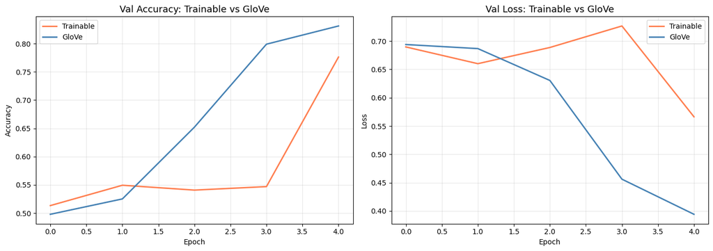

```python
fig, axes = plt.subplots(1, 2, figsize=(14, 5))

axes[0].plot(hist_trainable.history['val_accuracy'], label='Trainable', linewidth=2, color='coral')
axes[0].plot(hist_glove.history['val_accuracy'], label='GloVe', linewidth=2, color='steelblue')
axes[0].set_title('Val Accuracy: Trainable vs GloVe', fontsize=13)
axes[0].set_xlabel('Epoch'); axes[0].set_ylabel('Accuracy')
axes[0].legend(); axes[0].grid(True, alpha=0.3)

axes[1].plot(hist_trainable.history['val_loss'], label='Trainable', linewidth=2, color='coral')
axes[1].plot(hist_glove.history['val_loss'], label='GloVe', linewidth=2, color='steelblue')
axes[1].set_title('Val Loss: Trainable vs GloVe', fontsize=13)
axes[1].set_xlabel('Epoch'); axes[1].set_ylabel('Loss')
axes[1].legend(); axes[1].grid(True, alpha=0.3)

plt.tight_layout()
plt.show()
```

### Experiment with different max sequence lengths (100, 200, 300, 400)

```
Testing different MAX_LEN values...
============================================================

MAX_LEN = 100
  Test Accuracy: 0.7633

MAX_LEN = 200
  Test Accuracy: 0.6614

MAX_LEN = 300
  Test Accuracy: 0.5237

MAX_LEN = 400
  Test Accuracy: 0.5190
```

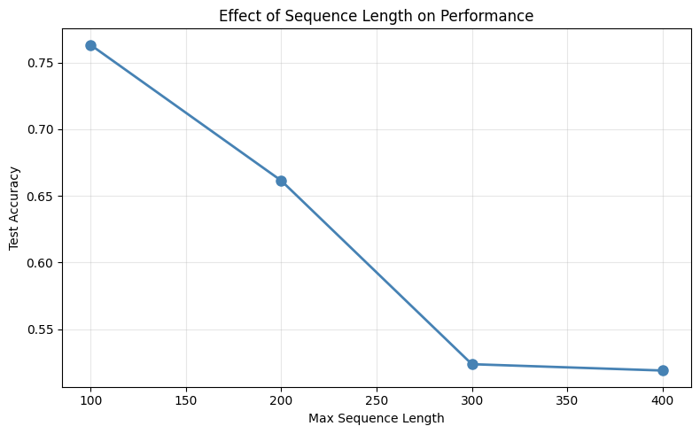

```
 MAX_LEN  Test Acc
     100   0.76332
     200   0.66144
     300   0.52372
     400   0.51896
```

```python
print("Testing different MAX_LEN values...")
print("="*60)

seq_len_results = []

for max_len_test in [100, 200, 300, 400]:
    print(f"\nMAX_LEN = {max_len_test}")

    X_tr_temp = pad_sequences(train_sequences, maxlen=max_len_test, padding='post', truncating='post')
    X_te_temp = pad_sequences(test_sequences, maxlen=max_len_test, padding='post', truncating='post')

    X_tr_temp = X_tr_temp[indices]
    X_val_temp = X_tr_temp[:num_val]
    X_tr_temp = X_tr_temp[num_val:]

    temp_model = models.Sequential([
        layers.Embedding(VOCAB_SIZE, EMBEDDING_DIM, weights=[embedding_matrix],
                         trainable=False),
        layers.LSTM(64, dropout=0.2, recurrent_dropout=0.2),
        layers.Dense(32, activation='relu'),
        layers.Dropout(0.3),
        layers.Dense(1, activation='sigmoid')
    ])
    temp_model.compile(optimizer='adam', loss='binary_crossentropy', metrics=['accuracy'])
    temp_model.fit(X_tr_temp, y_train_final, epochs=3, batch_size=BATCH_SIZE,
                   validation_data=(X_val_temp, y_val), verbose=0)
    _, test_acc = temp_model.evaluate(X_te_temp, test_labels, verbose=0)
    seq_len_results.append({'MAX_LEN': max_len_test, 'Test Acc': test_acc})
    print(f"  Test Accuracy: {test_acc:.4f}")

plt.figure(figsize=(8, 5))
lens = [r['MAX_LEN'] for r in seq_len_results]
accs = [r['Test Acc'] for r in seq_len_results]
plt.plot(lens, accs, 'o-', linewidth=2, markersize=8, color='steelblue')
plt.xlabel('Max Sequence Length'); plt.ylabel('Test Accuracy')
plt.title('Effect of Sequence Length on Performance')
plt.grid(True, alpha=0.3); plt.tight_layout(); plt.show()

print("\n" + pd.DataFrame(seq_len_results).to_string(index=False))
```

### Seq2Seq demo using a digit reversal task

```
Seq2Seq Demo: Sequence Reversal Task
============================================================
Encoder input (first 3): [[7 6 6 9 8 8 6 5 9 2]
 [7 6 7 4 9 7 2 4 5 2]
 [8 1 3 1 5 8 7 9 2 8]]
Decoder target (reversed): [[ 2  9  5  6  8  8  9  6  6  7 11]
 [ 2  5  4  2  7  9  4  7  6  7 11]
 [ 8  2  9  7  8  5  1  3  1  8 11]]

Training Seq2Seq with Teacher Forcing...
71/71 ━━━━━━━━━━━━━━━━━━━━ 4s 13ms/step - accuracy: 0.1889 - loss: 2.1851 - val_accuracy: 0.2411 - val_loss: 1.9783
71/71 ━━━━━━━━━━━━━━━━━━━━ 1s 8ms/step - accuracy: 0.3017 - loss: 1.8704 - val_accuracy: 0.3565 - val_loss: 1.7614
71/71 ━━━━━━━━━━━━━━━━━━━━ 1s 8ms/step - accuracy: 0.4093 - loss: 1.6237 - val_accuracy: 0.4807 - val_loss: 1.4682
71/71 ━━━━━━━━━━━━━━━━━━━━ 1s 8ms/step - accuracy: 0.5360 - loss: 1.3212 - val_accuracy: 0.5993 - val_loss: 1.1599
71/71 ━━━━━━━━━━━━━━━━━━━━ 1s 8ms/step - accuracy: 0.6411 - loss: 1.0373 - val_accuracy: 0.6802 - val_loss: 0.9269
71/71 ━━━━━━━━━━━━━━━━━━━━ 1s 8ms/step - accuracy: 0.7078 - loss: 0.8585 - val_accuracy: 0.7202 - val_loss: 0.8127
71/71 ━━━━━━━━━━━━━━━━━━━━ 1s 8ms/step - accuracy: 0.7544 - loss: 0.7285 - val_accuracy: 0.7885 - val_loss: 0.6606
71/71 ━━━━━━━━━━━━━━━━━━━━ 1s 8ms/step - accuracy: 0.8009 - loss: 0.6178 - val_accuracy: 0.8344 - val_loss: 0.5559
71/71 ━━━━━━━━━━━━━━━━━━━━ 1s 8ms/step - accuracy: 0.8302 - loss: 0.5422 - val_accuracy: 0.8469 - val_loss: 0.5017
71/71 ━━━━━━━━━━━━━━━━━━━━ 1s 7ms/step - accuracy: 0.8529 - loss: 0.4798 - val_accuracy: 0.8587 - val_loss: 0.4670
71/71 ━━━━━━━━━━━━━━━━━━━━ 1s 7ms/step - accuracy: 0.8686 - loss: 0.4332 - val_accuracy: 0.8785 - val_loss: 0.4121
71/71 ━━━━━━━━━━━━━━━━━━━━ 1s 8ms/step - accuracy: 0.8857 - loss: 0.3878 - val_accuracy: 0.8924 - val_loss: 0.3744
71/71 ━━━━━━━━━━━━━━━━━━━━ 1s 7ms/step - accuracy: 0.8978 - loss: 0.3523 - val_accuracy: 0.9045 - val_loss: 0.3481
71/71 ━━━━━━━━━━━━━━━━━━━━ 1s 8ms/step - accuracy: 0.9092 - loss: 0.3203 - val_accuracy: 0.9004 - val_loss: 0.3434
71/71 ━━━━━━━━━━━━━━━━━━━━ 1s 7ms/step - accuracy: 0.9196 - loss: 0.2918 - val_accuracy: 0.9140 - val_loss: 0.3112

Final Train Acc: 0.9196
Final Val Acc: 0.9140

--- Teacher Forcing vs Inference ---
Training: decoder gets the CORRECT previous token (faster learning)
Inference: decoder uses its OWN prediction (errors can pile up)
```

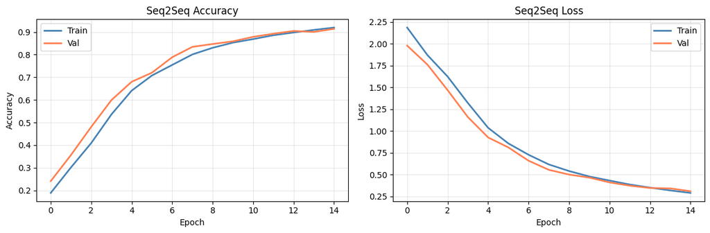

```python
print("Seq2Seq Demo: Sequence Reversal Task")
print("="*60)

SEQ_LEN_S2S = 10
NUM_TOKENS = 12
START_TOKEN = 10
END_TOKEN = 11

def generate_reversal_data(n_samples=5000):
    encoder_input = np.random.randint(1, 10, size=(n_samples, SEQ_LEN_S2S))
    decoder_input = np.zeros((n_samples, SEQ_LEN_S2S + 1), dtype=np.int32)
    decoder_target = np.zeros((n_samples, SEQ_LEN_S2S + 1), dtype=np.int32)
    for i in range(n_samples):
        reversed_seq = encoder_input[i][::-1]
        decoder_input[i, 0] = START_TOKEN
        decoder_input[i, 1:] = reversed_seq
        decoder_target[i, :SEQ_LEN_S2S] = reversed_seq
        decoder_target[i, SEQ_LEN_S2S] = END_TOKEN
    return encoder_input, decoder_input, decoder_target

enc_input, dec_input, dec_target = generate_reversal_data(5000)
print(f"Encoder input (first 3): {enc_input[:3]}")
print(f"Decoder target (reversed): {dec_target[:3]}")

# Encoder
encoder_inputs = layers.Input(shape=(SEQ_LEN_S2S,))
enc_emb = layers.Embedding(NUM_TOKENS, 32)(encoder_inputs)
enc_lstm = layers.LSTM(64, return_state=True)
enc_outputs, state_h, state_c = enc_lstm(enc_emb)
encoder_states = [state_h, state_c]

# Decoder
decoder_inputs = layers.Input(shape=(SEQ_LEN_S2S + 1,))
dec_emb = layers.Embedding(NUM_TOKENS, 32)(decoder_inputs)
dec_lstm = layers.LSTM(64, return_sequences=True)
dec_outputs = dec_lstm(dec_emb, initial_state=encoder_states)
dec_dense = layers.Dense(NUM_TOKENS, activation='softmax')
decoder_outputs = dec_dense(dec_outputs)

seq2seq_model = models.Model([encoder_inputs, decoder_inputs], decoder_outputs)
seq2seq_model.compile(optimizer='adam', loss='sparse_categorical_crossentropy', metrics=['accuracy'])

print("\nTraining Seq2Seq with Teacher Forcing...")
s2s_history = seq2seq_model.fit(
    [enc_input, dec_input], dec_target,
    epochs=15, batch_size=64, validation_split=0.1, verbose=1
)

print(f"\nFinal Train Acc: {s2s_history.history['accuracy'][-1]:.4f}")
print(f"Final Val Acc: {s2s_history.history['val_accuracy'][-1]:.4f}")

# Teacher Forcing explanation
print("\n--- Teacher Forcing vs Inference ---")
print("Training: decoder gets the CORRECT previous token (faster learning)")
print("Inference: decoder uses its OWN prediction (errors can pile up)")

fig, axes = plt.subplots(1, 2, figsize=(12, 4))
axes[0].plot(s2s_history.history['accuracy'], label='Train', color='steelblue', linewidth=2)
axes[0].plot(s2s_history.history['val_accuracy'], label='Val', color='coral', linewidth=2)
axes[0].set_title('Seq2Seq Accuracy'); axes[0].set_xlabel('Epoch'); axes[0].set_ylabel('Accuracy')
axes[0].legend(); axes[0].grid(True, alpha=0.3)

axes[1].plot(s2s_history.history['loss'], label='Train', color='steelblue', linewidth=2)
axes[1].plot(s2s_history.history['val_loss'], label='Val', color='coral', linewidth=2)
axes[1].set_title('Seq2Seq Loss'); axes[1].set_xlabel('Epoch'); axes[1].set_ylabel('Loss')
axes[1].legend(); axes[1].grid(True, alpha=0.3)

plt.tight_layout(); plt.show()
```

### Part 3 summary table — attention, embeddings, sequence lengths

```python
print("\nPart 3 Summary")
print("="*60)
p3_results = pd.DataFrame([
    {'Experiment': 'LSTM (no attention)', 'Test Acc': float(all_results[1]['Test Acc'])},
    {'Experiment': 'LSTM + Attention', 'Test Acc': attn_test_acc},
    {'Experiment': 'Trainable Embeddings', 'Test Acc': acc_trainable},
    {'Experiment': 'GloVe Embeddings', 'Test Acc': acc_glove},
])
for r in seq_len_results:
    p3_results = pd.concat([p3_results, pd.DataFrame([{
        'Experiment': f'MAX_LEN={r["MAX_LEN"]}', 'Test Acc': r['Test Acc']
    }])], ignore_index=True)

p3_results['Test Acc'] = p3_results['Test Acc'].map('{:.4f}'.format)
print(p3_results.to_string(index=False))
```

```
Part 3 Summary
============================================================
          Experiment Test Acc
 LSTM (no attention)   0.7198
    LSTM + Attention   0.8532
Trainable Embeddings   0.7695
    GloVe Embeddings   0.8222
         MAX_LEN=100   0.7633
         MAX_LEN=200   0.6614
         MAX_LEN=300   0.5237
         MAX_LEN=400   0.5190
```

## Part 4 — Optimization & Regularization (6 pts)

### Compare four dropout strategies: none, regular, recurrent, and both

```python
print("Comparing Dropout Strategies...")
print("="*60)

dropout_configs = [
    {'name': 'No Dropout',             'dropout': 0.0, 'rec_dropout': 0.0},
    {'name': 'Dropout=0.2',            'dropout': 0.2, 'rec_dropout': 0.0},
    {'name': 'Recurrent Dropout=0.2',  'dropout': 0.0, 'rec_dropout': 0.2},
    {'name': 'Both Dropout=0.3',       'dropout': 0.3, 'rec_dropout': 0.3},
]

dropout_histories = {}
dropout_results = []

for cfg in dropout_configs:
    print(f"\nTraining: {cfg['name']}")
    model = models.Sequential([
        layers.Embedding(VOCAB_SIZE, EMBEDDING_DIM, weights=[embedding_matrix],
                         trainable=False),
        layers.LSTM(64, dropout=cfg['dropout'], recurrent_dropout=cfg['rec_dropout']),
        layers.Dense(32, activation='relu'),
        layers.Dense(1, activation='sigmoid')
    ])
    model.compile(optimizer='adam', loss='binary_crossentropy', metrics=['accuracy'])
    hist = model.fit(X_train_final, y_train_final, epochs=EPOCHS, batch_size=BATCH_SIZE,
                     validation_data=(X_val, y_val), verbose=0)
    _, test_acc = model.evaluate(X_test, test_labels, verbose=0)

    dropout_histories[cfg['name']] = hist.history
    dropout_results.append({'Config': cfg['name'], 'Test Acc': f"{test_acc:.4f}",
                           'Val Acc': f"{hist.history['val_accuracy'][-1]:.4f}"})
    print(f"  Test Acc: {test_acc:.4f}")

print("\n" + pd.DataFrame(dropout_results).to_string(index=False))
```

```
Comparing Dropout Strategies...
============================================================

Training: No Dropout
  Test Acc: 0.8293

Training: Dropout=0.2
  Test Acc: 0.5557

Training: Recurrent Dropout=0.2
  Test Acc: 0.5720

Training: Both Dropout=0.3
  Test Acc: 0.5520

               Config Test Acc Val Acc
           No Dropout   0.8293  0.8354
          Dropout=0.2   0.5557  0.5534
Recurrent Dropout=0.2   0.5720  0.5698
     Both Dropout=0.3   0.5520  0.5406
```

### Train LSTM with layer normalization between stacked layers

```python
print("Training LSTM with Layer Normalization...")

model_ln = models.Sequential([
    layers.Embedding(VOCAB_SIZE, EMBEDDING_DIM, weights=[embedding_matrix],
                     trainable=False),
    layers.LSTM(64, return_sequences=True, dropout=0.2, recurrent_dropout=0.2),
    layers.LayerNormalization(),
    layers.LSTM(32, dropout=0.2, recurrent_dropout=0.2),
    layers.LayerNormalization(),
    layers.Dense(32, activation='relu'),
    layers.Dropout(0.3),
    layers.Dense(1, activation='sigmoid')
])

model_ln.compile(optimizer='adam', loss='binary_crossentropy', metrics=['accuracy'])
hist_ln = model_ln.fit(X_train_final, y_train_final, epochs=EPOCHS, batch_size=BATCH_SIZE,
                       validation_data=(X_val, y_val), verbose=1)
_, acc_ln = model_ln.evaluate(X_test, test_labels, verbose=0)
print(f"LSTM + LayerNorm Test Accuracy: {acc_ln:.4f}")
```

```
Training LSTM with Layer Normalization...
313/313 ━━━━━━━━━━━━━━━━━━━━ 381s 1s/step - accuracy: 0.5051 - loss: 0.7023 - val_accuracy: 0.5046 - val_loss: 0.6917
313/313 ━━━━━━━━━━━━━━━━━━━━ 373s 1s/step - accuracy: 0.5173 - loss: 0.6912 - val_accuracy: 0.5332 - val_loss: 0.6828
313/313 ━━━━━━━━━━━━━━━━━━━━ 375s 1s/step - accuracy: 0.5317 - loss: 0.6848 - val_accuracy: 0.5420 - val_loss: 0.6750
313/313 ━━━━━━━━━━━━━━━━━━━━ 380s 1s/step - accuracy: 0.5415 - loss: 0.6832 - val_accuracy: 0.5022 - val_loss: 0.6916
313/313 ━━━━━━━━━━━━━━━━━━━━ 374s 1s/step - accuracy: 0.5203 - loss: 0.6894 - val_accuracy: 0.5180 - val_loss: 0.6857
LSTM + LayerNorm Test Accuracy: 0.5325
```

### Compare optimizers (Adam, RMSprop, SGD) with gradient clipping enabled

```python
print("Comparing Optimizers (with gradient clipping)...")
print("="*60)

optimizer_configs = [
    {'name': 'Adam (lr=0.001)',         'opt': optimizers.Adam(learning_rate=0.001, clipnorm=1.0)},
    {'name': 'RMSprop (lr=0.001)',      'opt': optimizers.RMSprop(learning_rate=0.001, clipnorm=1.0)},
    {'name': 'SGD (lr=0.01, momentum)', 'opt': optimizers.SGD(learning_rate=0.01, momentum=0.9, clipnorm=1.0)},
    {'name': 'Adam (lr=0.0005)',        'opt': optimizers.Adam(learning_rate=0.0005, clipnorm=1.0)},
]

opt_histories = {}
opt_results = []

for cfg in optimizer_configs:
    print(f"\nTraining: {cfg['name']}")
    model = models.Sequential([
        layers.Embedding(VOCAB_SIZE, EMBEDDING_DIM, weights=[embedding_matrix],
                         trainable=False),
        layers.LSTM(64, dropout=0.2, recurrent_dropout=0.2),
        layers.Dense(32, activation='relu'),
        layers.Dropout(0.3),
        layers.Dense(1, activation='sigmoid')
    ])
    model.compile(optimizer=cfg['opt'], loss='binary_crossentropy', metrics=['accuracy'])
    hist = model.fit(X_train_final, y_train_final, epochs=EPOCHS, batch_size=BATCH_SIZE,
                     validation_data=(X_val, y_val), verbose=0)
    _, test_acc = model.evaluate(X_test, test_labels, verbose=0)

    opt_histories[cfg['name']] = hist.history
    opt_results.append({'Optimizer': cfg['name'], 'Test Acc': f"{test_acc:.4f}",
                       'Final Val Loss': f"{hist.history['val_loss'][-1]:.4f}"})
    print(f"  Test Acc: {test_acc:.4f}")

print("\n" + pd.DataFrame(opt_results).to_string(index=False))
```

```
Comparing Optimizers (with gradient clipping)...
============================================================

Training: Adam (lr=0.001)
  Test Acc: 0.7394

Training: RMSprop (lr=0.001)
  Test Acc: 0.7142

Training: SGD (lr=0.01, momentum)
  Test Acc: 0.5246

Training: Adam (lr=0.0005)
  Test Acc: 0.7066

              Optimizer Test Acc Final Val Loss
        Adam (lr=0.001)   0.7394         0.5687
     RMSprop (lr=0.001)   0.7142         0.5742
SGD (lr=0.01, momentum)   0.5246         0.6872
       Adam (lr=0.0005)   0.7066         0.5973
```

### Train with learning rate schedule (ReduceLROnPlateau) and early stopping

```python
print("Training with LR Schedule + Early Stopping...")

lr_model = models.Sequential([
    layers.Embedding(VOCAB_SIZE, EMBEDDING_DIM, weights=[embedding_matrix],
                     trainable=False),
    layers.LSTM(64, dropout=0.2, recurrent_dropout=0.2),
    layers.Dense(32, activation='relu'),
    layers.Dropout(0.3),
    layers.Dense(1, activation='sigmoid')
])

lr_model.compile(optimizer=optimizers.Adam(learning_rate=0.001, clipnorm=1.0),
                 loss='binary_crossentropy', metrics=['accuracy'])

lr_reducer = callbacks.ReduceLROnPlateau(monitor='val_loss', factor=0.5, patience=2, verbose=1)
early_stop = callbacks.EarlyStopping(monitor='val_loss', patience=3, restore_best_weights=True, verbose=1)

hist_lr = lr_model.fit(
    X_train_final, y_train_final,
    epochs=10, batch_size=BATCH_SIZE,
    validation_data=(X_val, y_val),
    callbacks=[lr_reducer, early_stop], verbose=1
)

_, acc_lr = lr_model.evaluate(X_test, test_labels, verbose=0)
print(f"\nLR Schedule + Early Stopping Test Acc: {acc_lr:.4f}")
```

```
Training with LR Schedule + Early Stopping...
313/313 ━━━━━━━━━━━━━━━━━━━━ 172s 538ms/step - accuracy: 0.5112 - loss: 0.6918 - val_accuracy: 0.5258 - val_loss: 0.6851 - learning_rate: 0.0010
313/313 ━━━━━━━━━━━━━━━━━━━━ 167s 533ms/step - accuracy: 0.6087 - loss: 0.6638 - val_accuracy: 0.6690 - val_loss: 0.6300 - learning_rate: 0.0010
313/313 ━━━━━━━━━━━━━━━━━━━━ 167s 534ms/step - accuracy: 0.6816 - loss: 0.6258 - val_accuracy: 0.7300 - val_loss: 0.6069 - learning_rate: 0.0010
313/313 ━━━━━━━━━━━━━━━━━━━━ 167s 534ms/step - accuracy: 0.7085 - loss: 0.5983 - val_accuracy: 0.7568 - val_loss: 0.5526 - learning_rate: 0.0010
313/313 ━━━━━━━━━━━━━━━━━━━━ 167s 532ms/step - accuracy: 0.7224 - loss: 0.5851 - val_accuracy: 0.7698 - val_loss: 0.5326 - learning_rate: 0.0010
313/313 ━━━━━━━━━━━━━━━━━━━━ 168s 536ms/step - accuracy: 0.7405 - loss: 0.5640 - val_accuracy: 0.7824 - val_loss: 0.5206 - learning_rate: 0.0010
313/313 ━━━━━━━━━━━━━━━━━━━━ 166s 530ms/step - accuracy: 0.7575 - loss: 0.5481 - val_accuracy: 0.7848 - val_loss: 0.5072 - learning_rate: 0.0010
313/313 ━━━━━━━━━━━━━━━━━━━━ 165s 527ms/step - accuracy: 0.7574 - loss: 0.5397 - val_accuracy: 0.7900 - val_loss: 0.5075 - learning_rate: 0.0010
313/313 ━━━━━━━━━━━━━━━━━━━━ 168s 536ms/step - accuracy: 0.7799 - loss: 0.4868 - val_accuracy: 0.8144 - val_loss: 0.4050 - learning_rate: 0.0010
313/313 ━━━━━━━━━━━━━━━━━━━━ 166s 531ms/step - accuracy: 0.8054 - loss: 0.4399 - val_accuracy: 0.8258 - val_loss: 0.3943 - learning_rate: 0.0010
Restoring model weights from the end of the best epoch: 10.

LR Schedule + Early Stopping Test Acc: 0.8214
```

### Plot all Part 4 results — dropout, optimizers, and LR schedule curves

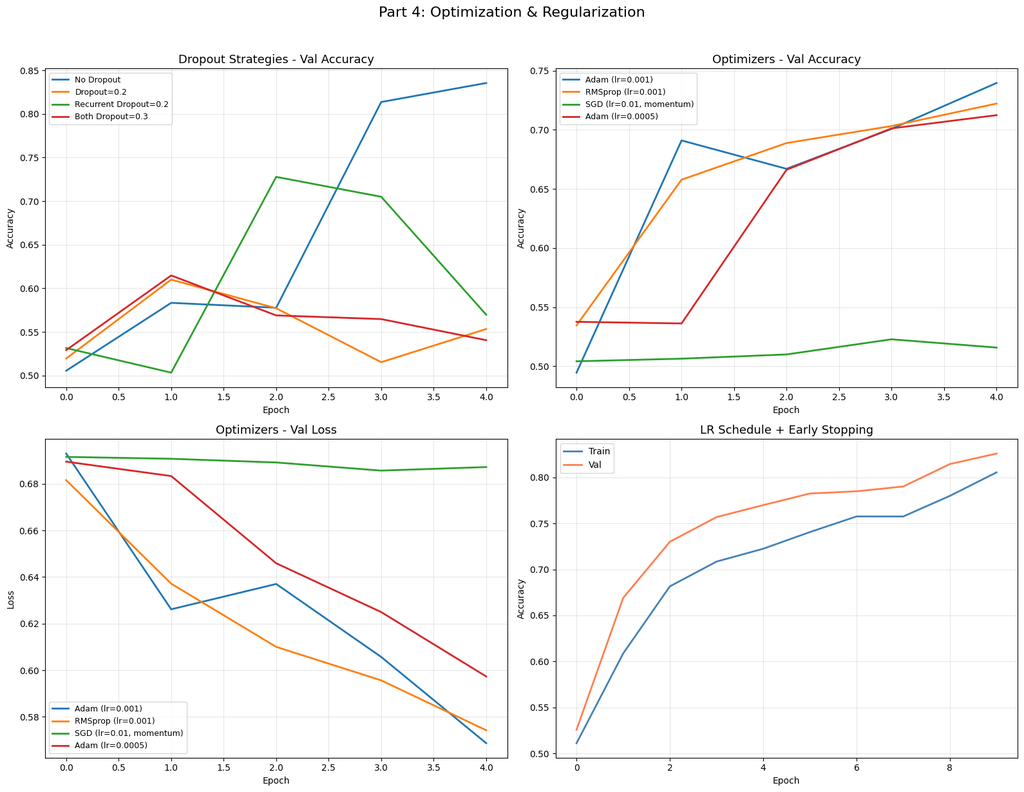

```python
fig, axes = plt.subplots(2, 2, figsize=(16, 12))

for name, hist in dropout_histories.items():
    axes[0, 0].plot(hist['val_accuracy'], label=name, linewidth=2)
axes[0, 0].set_title('Dropout Strategies - Val Accuracy', fontsize=13)
axes[0, 0].set_xlabel('Epoch'); axes[0, 0].set_ylabel('Accuracy')
axes[0, 0].legend(fontsize=9); axes[0, 0].grid(True, alpha=0.3)

for name, hist in opt_histories.items():
    axes[0, 1].plot(hist['val_accuracy'], label=name, linewidth=2)
axes[0, 1].set_title('Optimizers - Val Accuracy', fontsize=13)
axes[0, 1].set_xlabel('Epoch'); axes[0, 1].set_ylabel('Accuracy')
axes[0, 1].legend(fontsize=9); axes[0, 1].grid(True, alpha=0.3)

for name, hist in opt_histories.items():
    axes[1, 0].plot(hist['val_loss'], label=name, linewidth=2)
axes[1, 0].set_title('Optimizers - Val Loss', fontsize=13)
axes[1, 0].set_xlabel('Epoch'); axes[1, 0].set_ylabel('Loss')
axes[1, 0].legend(fontsize=9); axes[1, 0].grid(True, alpha=0.3)

axes[1, 1].plot(hist_lr.history['accuracy'], label='Train', linewidth=2, color='steelblue')
axes[1, 1].plot(hist_lr.history['val_accuracy'], label='Val', linewidth=2, color='coral')
axes[1, 1].set_title('LR Schedule + Early Stopping', fontsize=13)
axes[1, 1].set_xlabel('Epoch'); axes[1, 1].set_ylabel('Accuracy')
axes[1, 1].legend(); axes[1, 1].grid(True, alpha=0.3)

plt.suptitle('Part 4: Optimization & Regularization', fontsize=16, y=1.02)
plt.tight_layout()
plt.show()
```

### Part 4 summary — all optimization and regularization results

```python
print("Part 4 Summary")
print("="*60)
print("\nDropout Results:")
print(pd.DataFrame(dropout_results).to_string(index=False))
print(f"\nLayer Normalization Test Acc: {acc_ln:.4f}")
print("\nOptimizer Results:")
print(pd.DataFrame(opt_results).to_string(index=False))
print(f"\nLR Schedule + Early Stopping Test Acc: {acc_lr:.4f}")
print("\nAll models use gradient clipping (clipnorm=1.0) for stable training.")
```

[output not shown]

## Part 5 — Written Analysis & Reflection

### Written Analysis & Reflection

**Embedding and Sequence Length Findings:** GloVe embeddings (82.22%) beat trainable embeddings (76.95%), showing pre-trained word vectors give a stronger starting point. For sequence length, MAX_LEN=100 scored 76.33% while MAX_LEN=400 dropped to 51.90%. Longer sequences add more padding and need more training time to converge — with only 3 epochs, shorter sequences performed better.

**Bias and Fairness Concern:** The IMDB dataset contains English reviews from a specific user group. People who use slang or non-standard English may be misclassified — for example, "sick" can mean "terrible" or "amazing" depending on background. Our preprocessing removes rare words, potentially cutting out language used by minority communities. GloVe embeddings also carry biases from Wikipedia and news data, which can make certain groups' writing harder to classify correctly.

**Ethical Considerations for Deployment:** Using sentiment analysis in hiring or content moderation carries real risks. A biased model could reject candidates based on writing style rather than qualifications, or over-flag posts from certain communities. Before deploying, teams should test across demographic groups, provide appeal systems for wrong decisions, and keep humans in the loop for high-stakes choices. Transparency about the model's limits is essential.